# Tutoriel improvisé: Manipuler des données en Python avec pandas

Session de ~2h avec pour objectifs:

- "démarrage à froid" en Python: installation ([Anaconda](https://store.continuum.io/cshop/anaconda/)), prise en main du [Notebook IPython](http://ipython.org/notebook.html) [0h30]
- exploration rapide de Python numérique: calcul avec [numpy](http://www.numpy.org/), et tracés avec [Matplotlib](http://matplotlib.org/) [1h]
- objectif final: charger, manipuler et tracer les données d'un capteur de température et de CO2*, avec [pandas](http://pandas.pydata.org/) [1h]

**5 février 2015**, 14h-16h30, animé par Pierre Haessig

* *mise en abîme*: la session a lieu dans la salle où est installée ce capteur...

## 1) Démarrage

### a) Installation de Python

La distribution **Ananconda**, de *Continuum Analytics*, contient tous les paquets nécessaires pour une utilisation scientifique classique.

[lien direct de téléchargement](http://continuum.io/downloads) (300 Mo, gratuit)

→ choisir la version adaptée au système d'exploitation (e.g. 32 vs. 64 bits)

### b) Notebook IPython

*Sous Windows, dans le Menu Démarrer, lancer "Anaconda/IPython Notebook"*.

→ Ouvre une fenêtre de commande (le serveur) et une fenêtre de navigateur: l'interface du Notebook avec laquelle on va interagir

#### tour de l'interface

- Essayer dans le menu: "Help/User Interface Tour"
- introduction rapide au shell IPython: http://ipython.org/ipython-doc/dev/interactive/tutorial.html

Cellule de type "Code":

```python
a = 1
a+2
```

```
3
```

Cellule de type "Markdown":

- pour y écrire du texte (avec un peu de *mise en forme*, avec la syntaxe Markdown)
- et les équations Latex: $\theta = 1$

Aide sur la syntaxe: ["Markdown basics"](https://help.github.com/articles/markdown-basics/)

## 2) Exploration de Python numérique: Numpy et Matplotlib

Importer des modules (avec un alias court, plus pratique)

```python
import numpy as np
import matplotlib.pyplot as plt
```

Importer juste un élément:

```python
from numpy import pi
pi
```

```
3.141592653589793
```

Activer l'affichage des graphiques dans le Notebook (image statique)

```python
%matplotlib inline
```

Activer l'affichage dans une fenêtre séparé (interactif)

```python
%matplotlib qt
```

### Un petit tracé Matplotlib

Vecteur de données à tracer

```python
t = np.linspace(0, 4*pi)
y = np.sin(t)
```

Syntaxe de graphs avec Matplotlib: très proche de Matlab (volontairement)

Galerie d'exemples, très pratique pour découvrir: http://matplotlib.org/gallery.html

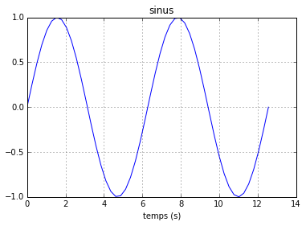

```python
plt.plot(t, y) # affiche y=f(t)
plt.title('sinus')
plt.xlabel('temps (s)')
plt.grid(True)
```

## 3) Lecture de données

```python
import pandas as pd
```

La "magic" `%ls` permet de lister le contenu d'un répertoire (comme `ls` sour Linux, `dir` sous Windows)

```python
%ls *.csv
```

```
log-20150128-092830.csv
```

Nom du fichier à lire (qui est ici dans le répertoire courant où le Notebook a été exécuté).

```python
%pwd
```

```
u'/home/pierre'
```

```python
fname = 'log-20150128-092830.csv'
```

Affichage du contenu du fichier:

- `head` et `tail` sous Linux (appel au shell avec le signe `!`)
- sinon magic `%more`

```python
!tail $fname
```

```python
# affiche *tout* le fichier dans le pager
%more $fname
```

### a) Lecture (parsing) du ficher CSV:

la fonction qui fait le travail: `read_csv`.

- (+) Pratique,
- (-) mais avec *beaucoup* d'options

```python
# Afficher l'aide (syntaxe spécifique à la console IPython)
pd.read_csv?
```

Appel simple, en précisant juste le séparateur des champs:

```python
d = pd.read_csv(fname, sep=';')
d.head()
```

|  | date | time | type | value | unit |
| --- | --- | --- | --- | --- | --- |
| 0 | 28/01/2015 | 09:28:45.871 | indoor relative humidity | 36.00 | % |
| 1 | 28/01/2015 | 09:29:44.274 | indoor relative humidity | 36.00 | % |
| 2 | 28/01/2015 | 09:30:46.377 | indoor relative humidity | 37.00 | % |
| 3 | 28/01/2015 | 09:30:50.697 | indoor temperature | 21.20 | �C |
| 4 | 28/01/2015 | 09:30:55.908 | volatile organic compounds | 0.06 | ppm |

→ Lecture sans erreur, mais les dates ne sont pas analysées (elles restent sous forme de chaînes de caractères)

```python
d['date'][0]
```

```
'28/01/2015'
```

```python
type(d['date'][0])
```

```
str
```

Appel de `read_csv` avec des options adaptées à ce fichier:

```python
d = pd.read_csv(fname, sep=';',
                parse_dates=[[0,1]], # aller chercher la date dans les 2 première colonnes
                index_col=0, # utiliser la date comme index des données
                dayfirst=True, # ne pas confondre le 5 février avec le 2 mai (format américain MM-DD-YYYY)
                )
d.head()
```

| date_time | type | value | unit |
| --- | --- | --- | --- |
| 2015-01-28 09:28:45.871000 | indoor relative humidity | 36.00 | % |
| 2015-01-28 09:29:44.274000 | indoor relative humidity | 36.00 | % |
| 2015-01-28 09:30:46.377000 | indoor relative humidity | 37.00 | % |
| 2015-01-28 09:30:50.697000 | indoor temperature | 21.20 | �C |
| 2015-01-28 09:30:55.908000 | volatile organic compounds | 0.06 | ppm |

### b) Manipulation des données

les donnés sont dans un `pandas.DataFrame`

```python
type(d)
```

```
pandas.core.frame.DataFrame
```

On récupère une colonne par indexation. Objet de type `Series`

```python
vals = d['value']
vals.head()
```

```
date_time
2015-01-28 09:28:45.871000    36.00
2015-01-28 09:29:44.274000    36.00
2015-01-28 09:30:46.377000    37.00
2015-01-28 09:30:50.697000    21.20
2015-01-28 09:30:55.908000     0.06
Name: value, dtype: float64
```

```python
type(vals)
```

```
pandas.core.series.Series
```

Tout les type de mesures issues du capteur

```python
type_meas = d['type']
type_meas.unique()
```

```
array(['indoor relative humidity', 'indoor temperature',
       'volatile organic compounds', 'carbon dioxide'], dtype=object)
```

Récupérer seulement un type de mesures: la température

```python
temp = vals[d['type'] == 'indoor temperature']
temp.head(3)
```

```
date_time
2015-01-28 09:30:50.697000    21.2
2015-01-28 09:33:49.494000    21.4
2015-01-28 09:36:51.682000    21.2
Name: value, dtype: float64
```

Exo: faire la même chose pour le CO2

```python
co2 = vals[d['type'] == 'carbon dioxide']
co2.head(3)
```

```
date_time
2015-01-28 09:31:01.408000    390
2015-01-28 09:33:59.015000    390
2015-01-28 09:37:01.512000    390
Name: value, dtype: float64
```

#### Statistique par groupes: `groupby`

Par type de mesure

```python
d.groupby('type').mean()
```

| type | value |
| --- | --- |
| carbon dioxide | 441.214809 |
| indoor relative humidity | 29.069816 |
| indoor temperature | 20.549659 |
| volatile organic compounds | 0.059591 |

Statistiques par jour

```python
temp.groupby(temp.index.dayofyear).mean()
```

```
28    21.091349
29    21.766250
30    21.304792
31    19.128750
32    18.576458
33    20.560417
34    21.048125
35    20.702917
36    21.225649
Name: value, dtype: float64
```

#### Changer la fréquence: rééchantillonage

Sous échantillonage: moyennes journalières

```python
temp.resample('1D')
```

```
date_time
2015-01-28    21.091349
2015-01-29    21.766250
2015-01-30    21.304792
2015-01-31    19.128750
2015-02-01    18.576458
2015-02-02    20.560417
2015-02-03    21.048125
2015-02-04    20.702917
2015-02-05    21.225649
Freq: D, Name: value, dtype: float64
```

Sur échantillonage: il faut combler les trous

```python
temp.resample('1Min').head()
```

```
date_time
2015-01-28 09:30:00    21.2
2015-01-28 09:31:00     NaN
2015-01-28 09:32:00     NaN
2015-01-28 09:33:00    21.4
2015-01-28 09:34:00     NaN
Freq: T, Name: value, dtype: float64
```

```python
temp.resample('1Min', fill_method='bfill').head()
```

```
date_time
2015-01-28 09:30:00    21.2
2015-01-28 09:31:00    21.4
2015-01-28 09:32:00    21.4
2015-01-28 09:33:00    21.4
2015-01-28 09:34:00    21.2
Freq: T, Name: value, dtype: float64
```

```python
temp.resample('1Min').interpolate().head()
```

```
date_time
2015-01-28 09:30:00    21.200000
2015-01-28 09:31:00    21.266667
2015-01-28 09:32:00    21.333333
2015-01-28 09:33:00    21.400000
2015-01-28 09:34:00    21.333333
Freq: T, Name: value, dtype: float64
```

### c) Tracé des données capteur

```python
%matplotlib inline
```

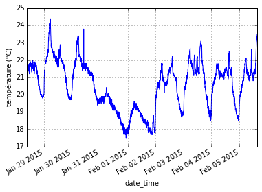

```python
temp.plot()
plt.ylabel(u'température (°C)') # u'' pour des textes accentués
```

Deux tracés sur le même axe: `twinx` (pb de grille non superposée)

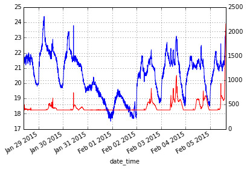

```python
temp.plot()
plt.twinx()
co2.plot(style='r');
```

La température et le CO2, superposés: `subplots`

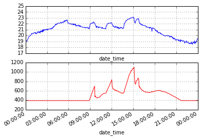

```python
fig, (ax1, ax2) = plt.subplots(2,1, sharex=True)

temp.plot(ax=ax1)

co2.plot(ax=ax2, style='r')
plt.xlim('2015-02-03','2015-02-04')
ax2.set_ylim(200, 1200);
```

Remarque: grâce au paramètre `sharex`, le zoom est synchronisé (utile en mode interactif, avec `%matplotlib qt`).